# NBA Stats

Stavrou Athanasios

16/8/2020

## Abstract

The purpose of this document is to implement some basic Machine Learning classification algorithms, such as logistic regression, classification trees and support vector machines. We will check the accuracy of these algorithms without tuning them (for example, there was no test (e.g. Elbow method) ran for the selection of the number of k folds in k fold cross validation algorithm, I arbitrarily used k=10), and in the end, we will compare this accuracy to the one that we get from randomly guessing the outcome.

## Descriptive Statistics

This is an attempt to analyze some NBA statistics. We will try to find if a rookie athlete will last for 5 or more seasons. It should be noted that in some cases we used different variations of the same algorithms, so that we show some different ways of implementing them.

Starting off, we import the data from the following URL:

```r
nba.df <- read.csv("https://query.data.world/s/4u6igngguoyjhzb7zksrgpiw6bqv6m", header=TRUE, stringsAsFactors=FALSE);
```

The dataset looks like this:

```r
head(nba.df)
```

```
##              Name GP  MIN PTS FGM FGA  FG. X3P.Made X3PA X3P. FTM FTA  FT. OREB
## 1  Brandon Ingram 36 27.4 7.4 2.6 7.6 34.7      0.5  2.1 25.0 1.6 2.3 69.9  0.7
## 2 Andrew Harrison 35 26.9 7.2 2.0 6.7 29.6      0.7  2.8 23.5 2.6 3.4 76.5  0.5
## 3  JaKarr Sampson 74 15.3 5.2 2.0 4.7 42.2      0.4  1.7 24.4 0.9 1.3 67.0  0.5
## 4     Malik Sealy 58 11.6 5.7 2.3 5.5 42.6      0.1  0.5 22.6 0.9 1.3 68.9  1.0
## 5     Matt Geiger 48 11.5 4.5 1.6 3.0 52.4      0.0  0.1  0.0 1.3 1.9 67.4  1.0
## 6    Tony Bennett 75 11.4 3.7 1.5 3.5 42.3      0.3  1.1 32.5 0.4 0.5 73.2  0.2
##   DREB REB AST STL BLK TOV TARGET_5Yrs
## 1  3.4 4.1 1.9 0.4 0.4 1.3           0
## 2  2.0 2.4 3.7 1.1 0.5 1.6           0
## 3  1.7 2.2 1.0 0.5 0.3 1.0           0
## 4  0.9 1.9 0.8 0.6 0.1 1.0           1
## 5  1.5 2.5 0.3 0.3 0.4 0.8           1
## 6  0.7 0.8 1.8 0.4 0.0 0.7           0
```

The dataset contains the following variables:

```
Name: First and Last name of the athlete
GP: Games Played
MIN: Minutes played per game
PTS: Points per game
FGM: Field Goal Made
FGA: Field Goal Attempted
FG: Field Goal Percentage
X3P.Made: 3-Points Made
X3PA: 3-Points Attempted
x3P.: 3-Points percentage
FTM: Free Throws Made per game
FTA: Free Throws Attempted per game
FT.: Free Throws percentage
OREB: Offensive Rebounds per game
DREB: Defensive Rebounds per game
REB: Rebounds per game
AST: Assists per game
STL: Steals per game
BLK: Blocks per game
TOV: Turnovers per game
TARGET_5Yrs: 1 if lasted >=5 Seasons, else 0 (Binary)
```

Checking for NA values:

```r
summary(is.na(nba.df))
```

```
##     Name             GP             MIN             PTS
##  Mode :logical   Mode :logical   Mode :logical   Mode :logical
##  FALSE:1340      FALSE:1340      FALSE:1340      FALSE:1340
##
##     FGM             FGA             FG.           X3P.Made
##  Mode :logical   Mode :logical   Mode :logical   Mode :logical
##  FALSE:1340      FALSE:1340      FALSE:1340      FALSE:1340
##
##     X3PA            X3P.            FTM             FTA
##  Mode :logical   Mode :logical   Mode :logical   Mode :logical
##  FALSE:1340      FALSE:1329      FALSE:1340      FALSE:1340
##                  TRUE :11
##     FT.             OREB            DREB            REB
##  Mode :logical   Mode :logical   Mode :logical   Mode :logical
##  FALSE:1340      FALSE:1340      FALSE:1340      FALSE:1340
##
##     AST             STL             BLK             TOV
##  Mode :logical   Mode :logical   Mode :logical   Mode :logical
##  FALSE:1340      FALSE:1340      FALSE:1340      FALSE:1340
##
##  TARGET_5Yrs
##  Mode :logical
##  FALSE:1340
##
```

We notice that there are 11 3-Point percentage shots missing. This is a rather small number of observations, so omitting them would not mean that we would lose much information. However, the we do know the 3-Points Attempted and the 3-Point Made for these observations, so we can fill the NA values by calculating the percentage ourselves. If we print these two variables, we see that these athletes did not attempt any 3-Point shots, so we will replace the percentage with 0%. Finally, we remove the athletes’ names from the dataframe, but we store them into another, new variable called “athletes”.

```r
NA_ind <- which(is.na(nba.df$X3P.));
nba.df$X3P.Made[NA_ind]
```

```
##  [1] 0 0 0 0 0 0 0 0 0 0 0
```

```r
nba.df$X3PA[NA_ind]
```

```
##  [1] 0 0 0 0 0 0 0 0 0 0 0
```

```r
nba.df$X3P.[NA_ind] <- 0;
summary(is.na(nba.df))
```

```
##     Name             GP             MIN             PTS
##  Mode :logical   Mode :logical   Mode :logical   Mode :logical
##  FALSE:1340      FALSE:1340      FALSE:1340      FALSE:1340
##     FGM             FGA             FG.           X3P.Made
##  Mode :logical   Mode :logical   Mode :logical   Mode :logical
##  FALSE:1340      FALSE:1340      FALSE:1340      FALSE:1340
##     X3PA            X3P.            FTM             FTA
##  Mode :logical   Mode :logical   Mode :logical   Mode :logical
##  FALSE:1340      FALSE:1340      FALSE:1340      FALSE:1340
##     FT.             OREB            DREB            REB
##  Mode :logical   Mode :logical   Mode :logical   Mode :logical
##  FALSE:1340      FALSE:1340      FALSE:1340      FALSE:1340
##     AST             STL             BLK             TOV
##  Mode :logical   Mode :logical   Mode :logical   Mode :logical
##  FALSE:1340      FALSE:1340      FALSE:1340      FALSE:1340
##  TARGET_5Yrs
##  Mode :logical
##  FALSE:1340
```

```r
athletes <- nba.df[,1]
nba.df <- nba.df[,-c(1)]
```

Before splitting the dataset, some graphs to better understand our data. We plot the distributions for minutes played, turnovers, turnovers vs. assists and assits vs. steals. We plot them for both groups, “0” is the group that did not last for more than 5 seasons in the NBA, while 1 represents the group that lasted for more than 5 years.

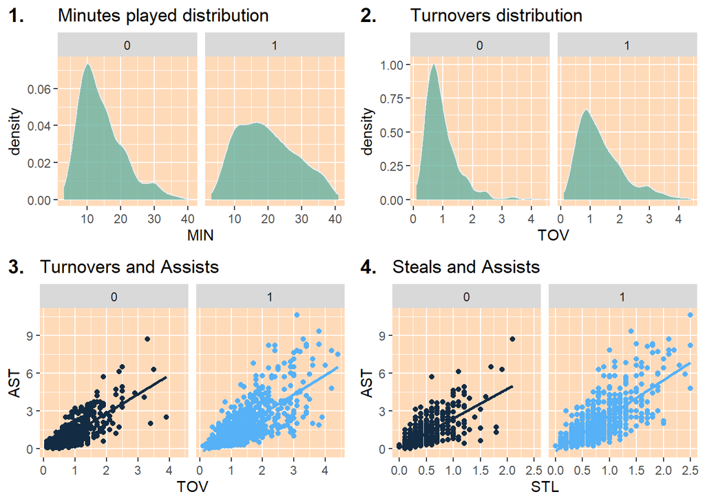

```r
library(ggplot2)
library(dplyr)
library(GGally)
library(ggpubr)
library(hrbrthemes)

graph1 <- ggplot(data=nba.df, aes(x=MIN, col=TARGET_5Yrs))+
  geom_density(fill="#69b3a2", color="#e9ecef", alpha=0.8)+
  facet_grid(~TARGET_5Yrs)

graph1 <- graph1+labs(title = "Minutes played distribution")+
  theme(panel.background = element_rect(fill = "peachpuff"))


graph2 <- ggplot(data=nba.df, aes(x=TOV, col=TARGET_5Yrs))+
  geom_density(fill="#69b3a2", color="#e9ecef", alpha=0.8)+
  facet_grid(~TARGET_5Yrs)

graph2 <- graph2+labs(title = "Turnovers distribution")+
  theme(panel.background = element_rect(fill = "peachpuff"))


graph3 <- ggplot(data=nba.df, aes(x=TOV, y=AST, col=TARGET_5Yrs))+
  geom_point()+
  geom_smooth(method = 'lm', se = F)+
  facet_grid(~TARGET_5Yrs)

graph3 <- graph3+labs(title = "Turnovers and Assists")+
  theme(panel.background = element_rect(fill = "peachpuff"),legend.position = "none")


graph4 <- ggplot(data=nba.df, aes(x=STL, y=AST, col=TARGET_5Yrs))+
  geom_point()+
  geom_smooth(method = 'lm', se = F)+
  facet_grid(~TARGET_5Yrs)

graph4 <- graph4+labs(title = "Steals and Assists")+
  theme(panel.background = element_rect(fill = "peachpuff"),legend.position = "none")



figure <- ggarrange(graph1, graph2, graph3, graph4,
                     labels = c("1.", "2.", "3.", "4."),
                     ncol = 2, nrow = 2)
figure
```

Graphs 3 and 4 are two scatterplots with trend lines, showing the relationship of assists with turnovers and steals. Both turnovers and steals correlate with the average assist number per game. Higher turnover rate for athletes (esp. rookies) who attempt more assists on average was to be expected, due to taking higher risk when throwing a pass. However, the number of steals affecting the number of assists has no logical explanation, so maybe this correlation is spurious. However, we will not look into it, as this is not the purpose of this presentation (for those interested, follow this link: https://bit.ly/3av3m7X).

## Splitting the dataset

Now, we split the dataset into training and testing sets:

```r
set.seed(41)
indices = 1:nrow(nba.df)
trainIndex = sample(x = indices,size = floor(0.6*nrow(nba.df)),replace = F)
train = nba.df[trainIndex,]
temp_test = nba.df[-trainIndex,]
```

To be more unbiased, we break the temp_test dataset into a new testing and a cross validation test:

```r
indices = 1:nrow(temp_test)
testIndex = sample(x = indices,size = floor(0.5*nrow(temp_test)),replace = F)
test = temp_test[testIndex,]
cv = temp_test[-testIndex,]
```

```r
dim(train)
```

```
## [1] 804  20
```

```r
dim(test)
```

```
## [1] 268  20
```

```r
dim(cv)
```

```
## [1] 268  20
```

We find the find the important variables using the Boruta method (note that this is for interpretation purposes and not for predictions):

```r
library(Boruta)
borutafit <- Boruta(TARGET_5Yrs~., data=train, doTrace=2)
print(borutafit)
```

```
## Boruta performed 99 iterations in 30.82008 secs.
##  14 attributes confirmed important: DREB, FG., FGA, FGM, FTA and 9
## more;
##  3 attributes confirmed unimportant: BLK, X3P.Made, X3PA;
##  2 tentative attributes left: AST, FT.;
```

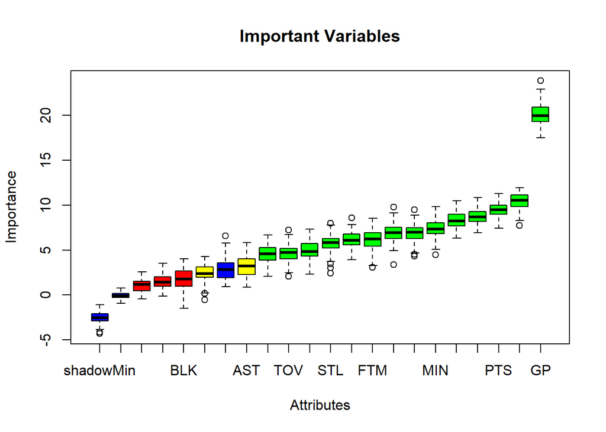

```r
plot(borutafit, main = "Important Variables")
```

From the plot above, we see that the most important variable to predict whether the rookie lasted or not is the number of games played, while the number of blocks, 3-point shots made and attempted did not matter. In case our main purpose was to interpret the model, we would drop these variables. However, we are keeping them for higher accuracy. This figure shows the improtance of each variable, so if, for example, we use classification trees, we expect to see that the first split will be made based on Games Played (GP).

## Predicting with Logistic Regression

We fit a logistic regression model on our data, and then we compute the accuracy of our predictions on the cross validation test.

```r
logit <- glm(TARGET_5Yrs ~., data = train, family = "binomial")
summary(logit)
```

```
##
## Call:
## glm(formula = TARGET_5Yrs ~ ., family = "binomial", data = train)
##
## Deviance Residuals:
##     Min       1Q   Median       3Q      Max
## -3.0078  -1.0076   0.5300   0.8956   2.2039
##
## Coefficients:
##              Estimate Std. Error z value Pr(>|z|)
## (Intercept) -4.577404   1.526084  -2.999   0.0027 **
## GP           0.034203   0.006032   5.671 1.42e-08 ***
## MIN         -0.053286   0.042242  -1.261   0.2071
## PTS         -0.272528   1.126207  -0.242   0.8088
## FGM          0.122282   2.240748   0.055   0.9565
## FGA          0.232972   0.291471   0.799   0.4241
## FG.          0.022375   0.026561   0.842   0.3996
## X3P.Made     3.672189   1.700186   2.160   0.0308 *
## X3PA        -1.118940   0.512790  -2.182   0.0291 *
## X3P.         0.009388   0.006779   1.385   0.1661
## FTM          0.691160   1.285091   0.538   0.5907
## FTA         -0.212324   0.571803  -0.371   0.7104
## FT.          0.018562   0.012197   1.522   0.1281
## OREB         0.398041   1.631070   0.244   0.8072
## DREB        -0.848164   1.631415  -0.520   0.6031
## REB          0.723712   1.624214   0.446   0.6559
## AST          0.326725   0.142568   2.292   0.0219 *
## STL         -0.346060   0.400387  -0.864   0.3874
## BLK          0.405571   0.322007   1.260   0.2078
## TOV         -0.149032   0.355631  -0.419   0.6752
## ---
## Signif. codes:  0 '***' 0.001 '**' 0.01 '*' 0.05 '.' 0.1 ' ' 1
##
## (Dispersion parameter for binomial family taken to be 1)
##
##     Null deviance: 1076.62  on 803  degrees of freedom
## Residual deviance:  900.82  on 784  degrees of freedom
## AIC: 940.82
##
## Number of Fisher Scoring iterations: 4
```

```r
logit_prob <- predict(logit, newdata = cv, type = "response")
logit_pred <- rep(0, dim(cv)[1])
logit_pred[logit_prob > .5] <- 1
table(predicted = logit_pred, actual = cv$TARGET_5Yrs)
```

```
##          actual
## predicted   0   1
##         0  62  38
##         1  37 131
```

```r
mean(nba.df[,20]) #probability that we correctly predict that the rookie lasted for more than 5 seasons if we guess
```

```
## [1] 0.6201493
```

```r
mean(logit_pred == cv$TARGET_5Yrs) #probability that we predict if the rookie lasted using the model
```

```
## [1] 0.7201493
```

We see that our model correctly predicts 72% of the data with this method, which is better than randomly guessing (which is 62%).

## Predicting with LOOCV

Leave one out Cross Validation method works as follow: 1. Leave one data point out and train on the rest of the data 2. Test the model on the data point left out and record the prediction error 3. Repeat for all data points 4. Compute overall prediction error by averaging all predictions errors from step 2

```r
require(caret)
set.seed(120)
# Define training control
train.control <- trainControl(method = "LOOCV")
# Train the model
loocv <- train(as.factor(TARGET_5Yrs) ~., data = train, method = "bayesglm",
               trControl = train.control)
# Summarize the results
print(loocv)
```

```
## Bayesian Generalized Linear Model
##
## 804 samples
##  19 predictor
##   2 classes: '0', '1'
##
## No pre-processing
## Resampling: Leave-One-Out Cross-Validation
## Summary of sample sizes: 803, 803, 803, 803, 803, 803, ...
## Resampling results:
##
##   Accuracy  Kappa
##   0.699005  0.3455103
```

```r
loocv_pred <- predict(loocv, newdata = cv)
table(predicted = loocv_pred, actual = cv$TARGET_5Yrs)
```

```
##          actual
## predicted   0   1
##         0  58  40
##         1  41 129
```

```r
mean(loocv_pred == cv$TARGET_5Yrs)
```

```
## [1] 0.6977612
```

We now have lower accuracy than logistic regression. However, the positive about this algorithm is the fact that it tests the model on every data point, so the bias is expected to be lower. The con is that because of training and testing for every data point, it is way slower than using logistic regression.

## Predicting with kfold cross-validation

To avoid the con mentioned above, we will predict by using kfold cross-validation. This algorithm works similarly to LOOCV, but instead of using every data points it uses k subsets of the dataset. We will repeat this process 3 times, so that the split of the subsets becomes “more” random.

```r
set.seed(223)
train.control <- trainControl(method = "repeatedcv",
                              number = 10, repeats = 3)
# Train the model
rkfold <- train(as.factor(TARGET_5Yrs) ~., data = train, method = "bayesglm",
                trControl = train.control)
# Summarize the results
print(rkfold)
```

```
## Bayesian Generalized Linear Model
##
## 804 samples
##  19 predictor
##   2 classes: '0', '1'
##
## No pre-processing
## Resampling: Cross-Validated (10 fold, repeated 3 times)
## Summary of sample sizes: 724, 724, 725, 723, 723, 723, ...
## Resampling results:
##
##   Accuracy   Kappa
##   0.7032074  0.3538229
```

```r
rkfold_pred <- predict(rkfold, newdata = cv)
table(predicted = rkfold_pred, actual = cv$TARGET_5Yrs)
```

```
##          actual
## predicted   0   1
##         0  58  40
##         1  41 129
```

```r
mean(rkfold_pred == cv$TARGET_5Yrs)
```

```
## [1] 0.6977612
```

We notice that the accuracy remains the same.

## Predicting with Support Vector Machines method

Moving forward, we will test how SVM predicts our cv data:

```r
require(e1071)
svmfit <- svm(TARGET_5Yrs ~ ., data = train, scale = FALSE, kernel = "linear")
svm_pred <- predict(svmfit, cv)
svm_pred <- as.factor(ifelse(svm_pred <= 0.5, 0, 1))
table(predicted = svm_pred, actual = cv$TARGET_5Yrs)
```

```
##          actual
## predicted   0   1
##         0  58  34
##         1  41 135
```

```r
mean(svm_pred == cv$TARGET_5Yrs)
```

```
## [1] 0.7201493
```

We notice that even though the confusion matrix has a different distribution from the logit model, it has exactly the same accuracy, so in terms of accuracy, the two models are equal.

## Predicting with Classification Trees

We now implement classification tree on our training data.

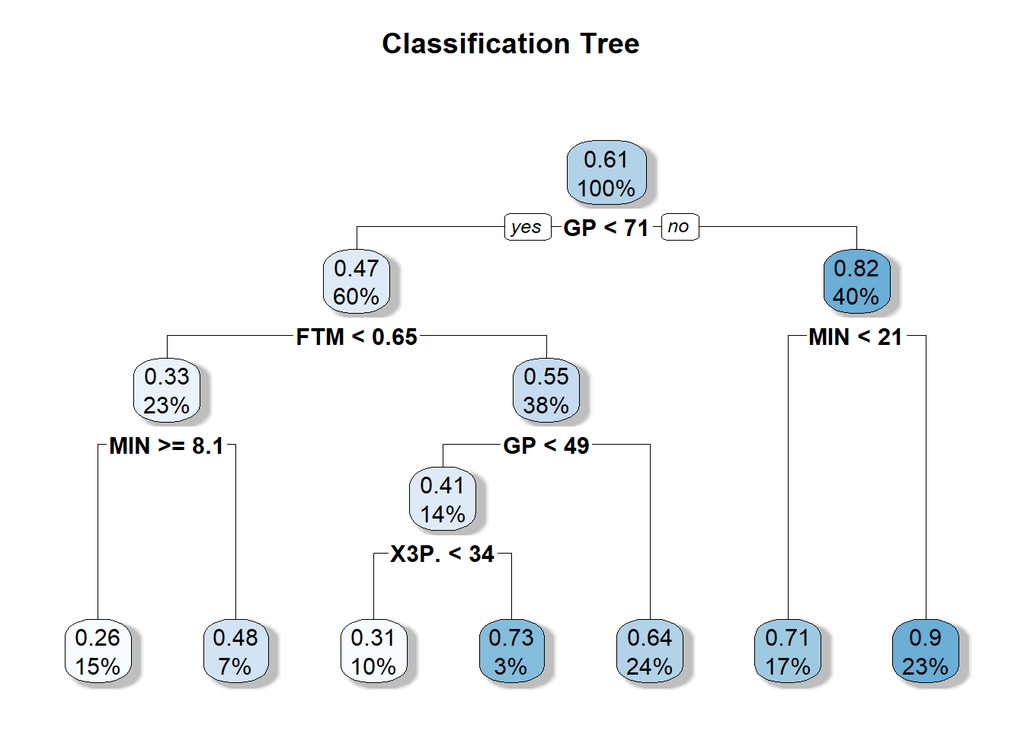

```r
require(rpart.plot)
dt <- rpart(TARGET_5Yrs ~ ., data = train)
rpart.plot(dt,
           shadow.col = "gray",
           main = "Classification Tree\n")
```

```r
dt_pred <- predict(dt, cv)
dt_pred <- as.factor(ifelse(dt_pred <= 0.5, 0, 1))
table(predicted = dt_pred, actual = cv$TARGET_5Yrs)
```

```
##          actual
## predicted   0   1
##         0  62  46
##         1  37 123
```

```r
mean(dt_pred == cv$TARGET_5Yrs)
```

```
## [1] 0.6902985
```

We see that the accuracy has dropped to 69%.

## Predicting with Random Forests

In this section we implement a tuned Random Forest algorithm. We set the seed and then train our model. We check which ntree number has the lower Out Of Bad (OOB) error rate, and then we train again our model with optimal “ntree” parameter:

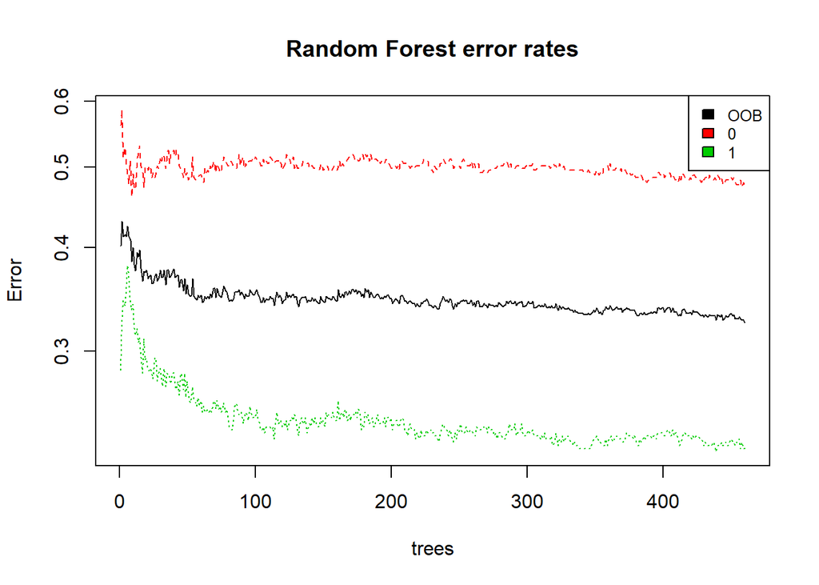

```r
require(randomForest)
set.seed(123)
rf <- randomForest(as.factor(TARGET_5Yrs) ~ ., data = train, ntree = 500, mtry = 6, importance = TRUE)
n <- which.min(rf$err.rate[,1])
set.seed(123)
rf <- randomForest(as.factor(TARGET_5Yrs) ~ ., data = train, ntree = n, mtry = 6, importance = TRUE)
rf_pred <- predict(rf, cv)

plot(rf, log="y", main = "Random Forest error rates")
legend("topright", colnames(rf$err.rate),col=1:4,cex=0.8,fill=1:4)
```

```r
mean(rf_pred == cv$TARGET_5Yrs)
```

```
## [1] 0.7126866
```

We notice that our accuracy has is now 71.27%, which is lower than both SVM and logit, but it is higher than classification trees.

## Final prediction

```r
set.seed(555)
logit_prob_final <- predict(logit, newdata = test, type = "response")
logit_pred_final <- rep(0, dim(test)[1])
logit_pred_final[logit_prob_final > .5] <- 1
table(predicted = logit_pred_final, actual = test$TARGET_5Yrs)
```

```
##          actual
## predicted   0   1
##         0  49  32
##         1  46 141
```

```r
mean(logit_pred_final == test$TARGET_5Yrs)
```

```
## [1] 0.7089552
```

So, in the end, we get 71% accuracy, which is about 10% better of the random guess.

## Conclusions

We saw that every algorithms improves our accuracy for about 8% to 9%. We got these results without fine-tuning our algorithms, meaning that we can probably get even higher percentages. Does this document imply that the best classification algorithms is logit or SVM? The answer is no. The fact that in this case we got better results off these two algorithms do not prove that, in fact, every case is different. The best algorithm could cary based on the number of features, observations, etc. Also, in many cases, it could be that we use simpler and computationally lighter algorithms over heavier ones, if the outcomes do not vary that much. As a reminder, always try simpler methods first, most of the times they produce satisfying results :)